# Zwei eingefrorene Leser, eine Frage: „Wer ist Adolf Hitler?“ (deutsch)

Dieselbe Frage, hundertmal, freie Fortsetzung (Temperatur 0.8). **Ranke 1913** hat nichts nach 1913 gelesen; **Ranke 1929** nichts nach 1929. 1913 war Hitler ein unbekannter 24-Jaehriger in Wien; 1929 war er der Fuehrer der NSDAP, Verfasser von *Mein Kampf* (1925), verurteilt wegen des Muenchner Putsches von 1923 — aber noch **nicht** Reichskanzler (Januar 1933).

## Was jedes Modell sagt (100 freie Fortsetzungen, Prompt „Adolf Hitler ist“)

| Kategorie | Ranke 1913 | Ranke 1929 |
| --- | --- | --- |
| identifies the real agitator (National Socialists / Hitler-Putsch / voelkisch) | 0% | 7% |
| names Munich/Reichstag but confabulates (no real identity) | 12% | 32% |
| generic confabulation (name treated as an unknown person) | 88% | 61% |

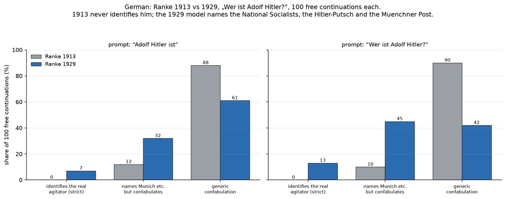

x-Achse: die drei Kategorien; y-Achse: Anteil der 100 Fortsetzungen. Grau = 1913, blau = 1929. Links der definitorische Prompt, rechts die Frage.

## Ranke 1929 — echtes Wissen (Auszuege)

- ein Mann, der von einem großen Gedanken beseelt war. Er hat es verstanden, mit seiner Person eine starke Bewegung zu entfachen und auch die große Masse des Volkes in seinen Bannkreis z» ziehen: denn er wußte sein Volk
- , obwohl noch nicht 30 Jahre alt und unverheiratet , ein Führer der Kommunisten in Berlin . Die „ Münchner Post “ schreibt über ihn : Adolf Hitler war von Beruf Bauarbeiter ; als solcher hatte er Ge
- nicht mehr Reichs- kanzler, sondern nur noch Oberpräsident von Bayern. Er hat den Kampf gegen die Nationalsozialisten aufgegeben; er hat sich mit ihnen verbrüdert und ihre Führer zu Rat geber» in der Regierung gemacht.
- in den letzten Jahren mehrfach mit seinem Anhang aus der Schweiz vertrieben worden. Die neue Verhaftung wird damit erklärt, daß die Regierung von Zürich wegen des Hilter- putsches gegen das dortige Asylrecht verstößt hat. Das Vorge
- der Führer der Nationalsozialisten, die eine Partei von 50 900 Mitgliedern bilden. Diese Tatsache hat man in den letzten Monaten wiederholt erwähnt und ausgesprochen. Immerhin sind aber auch andere Leute
- , wie aus Berlin gemeldet wird, der Münchener Studentenführer Adolf Hitler (ein Sohn des bekannten Führers der völkischen Bewegung) von dem preußischen Polizeipräsidenten aufgefordert worden, die Reichshauptstadt
- , wie er selbst in der „Münchner Post" schreibt, von einer unbestimmten Idee verleitet und im Irrtum. Er hoffte die Masse des Volkes gegen den Kapitalismus mobil zu machen und hat sich dabei getäuscht

## Ranke 1913 — die „Treffer“ sind Konfabulation (Auszuege)

- 23 Jahre alt. Er wurde in München geboren und studierte Medizin an der dortigen Universität, erhielt aber einen Ruf als Assistenten nach Zürich. Von da ging es ihm durch die Schweiz und das nördliche Deutschland; dann wandte sich
- aus der Haft entlassen worden . Einige Stunden nach seiner Entlassung hat er sich selbst in seinem Hotel erschossen. München , 12 . März - Die Kammer genehmigte die Be willigung von 850,000 M zur Herstellung des
- auf Antrag seiner Gläubiger, die ihre Forderungen durch den Kgl. Notar Herrn Carl Stürken in München geltend machen lassen werden, unter der Vormundschaft seines Sohnes und Schwiegersohnes, des Privatiers Karl Z
- in München im Alter von 54 Jahren gestorben. Er war ein großer Gelehrter, aber auch als Mensch und Künstler voll Schneidigkeit, Lebhaftig keit und Witz. Der Verstorbene hat sich nicht nur um die
- in München gestorben. Der neue Botschafter der Vereinigten Staaten von Amerika, Mr. Wilson, wird dem König vor seiner Ankunft am Montag eine Antrittsbesuchs machen und sich dann nach Berlin begeben. Die „Nordd. All
- heute Nacht 1 Uhr in der Narkose im städtischen Krankenhause Westend gestorben. Infolge des Todes dieses Mannes, eines der bekanntesten Führer und Verfechter der christlich-sozialen Arbeiterbewegung wird sich die
- nicht der einzige, welcher die Schäden des heutigen Wirtshauswesens im Reichstag besprochen hat. Auch Abgeordnete anderer Partei en haben sich in gleichem Sinne geäußert und bezeichnenderweise mit

## Kein Modell kennt 1933

Wo das 1929er-Modell „Reichskanzler“ sagt, konfabuliert es Weimarer Kabinettspolitik (Marx, Wirth) oder knuepft an den Putsch von 1923 an; keine Fortsetzung nennt die Machtergreifung 1933. Das 1929er-Modell kennt den aufsteigenden Agitator der zwanziger Jahre — nicht das Ende der Geschichte.